# titanic

## O Danych

Dane o pasażerach Titanica

Zbiór danych zawiera informacje o pasażerach RMS Titanic, który zatonął 15 kwietnia 1912 roku po zderzeniu z górą lodową. Dane obejmują takie atrybuty jak klasa podróży, wiek, płeć, liczba rodzeństwa/małżonków na pokładzie, liczba rodziców/dzieci na pokładzie, cena biletu oraz miejsce zaokrętowania.

Zbiór zawiera także informację o tym, czy pasażer przeżył katastrofę.

Titanic przewoził ponad 2,200 osób, z czego ponad 1,500 zginęło, co czyni tę katastrofę jedną z najbardziej tragicznych w historii morskiej.

Kolumny:

- **pclass** - Klasa biletu
- **survived** - Czy pasażer przeżył katastrofę
- **name** - Imię i nazwisko pasażera
- **sex** - Płeć pasażera
- **age** - Wiek pasażera
- **sibsp** - Liczba rodzeństwa/małżonków na pokładzie
- **parch** - Liczba rodziców/dzieci na pokładzie
- **ticket** - Numer biletu
- **fare** - Cena biletu
- **cabin** - Numer kabiny
- **embarked** - Port, w którym pasażer wszedł na pokład (C = Cherbourg, Q = Queenstown, S = Southampton)
- **boat** - Numer łodzi ratunkowej
- **body** - Numer ciała (jeśli pasażer nie przeżył i ciało zostało odnalezione)
- **home.dest** - Miejsce docelowe

[figure not shown]

```python
# Grafika stworzona przez Gemini
from IPython.display import Image, display

display(Image("Titanic crash.png"))
```

# 0. Wstęp - rys historyczny

Rys Historyczny Zatonięcia RMS Titanic (1912)

📉 Tło i Kontekst Statku

RMS Titanic był drugim z trzech bliźniaczych transatlantyków klasy Olympic, zbudowanych dla towarzystwa żeglugowego White Star Line w stoczni Harland and Wolff w Belfaście. Był to wówczas największy i najbardziej luksusowy statek pasażerski świata, okrzyknięty mianem „niezatapialnego” ze względu na nowatorską konstrukcję kadłuba podzielonego na 16 wodoszczelnych przedziałów.

Jego dziewiczy rejs rozpoczął się 10 kwietnia 1912 roku z Southampton, a celem był Nowy Jork. Statek zatonął w nocy z 14 na 15 kwietnia 1912 roku, po uderzeniu w górę lodową na północnym Atlantyku. Zginęło ponad 1500 osób, co uczyniło tę katastrofę jedną z największych w historii żeglugi w czasach pokoju.

🧊 Główne Przyczyny Katastrofy

Choć bezpośrednią przyczyną było zderzenie z górą lodową, do katastrofy przyczyniła się kombinacja czynników:

```
Zderzenie z Górą Lodową:

   - Zbyt duża prędkość: Statek płynął z dużą prędkością (ok. 22 węzłów) pomimo wielokrotnych ostrzeżeń o lodzie dryfującym, co było częściowo motywowane chęcią dotrzymania harmonogramu i wypracowania rekordu.

   - Późne wykrycie: Brak lornetek dla obserwatorów (lookoutów) na gnieździe bocianim oraz bezksiężycowa noc utrudniły wczesne dostrzeżenie góry. Gdy ją zauważono, czas na manewr był zbyt krótki.

   - Charakter uszkodzeń: Uderzenie nie nastąpiło frontalnie, lecz z boku, powodując serię pęknięć i wgnieceń poniżej linii wodnej wzdłuż bocznej burty na długości około 90 metrów. To naruszyło szczelność sześciu z szesnastu wodoszczelnych przedziałów. Titanic mógł utrzymać się na powierzchni przy zalaniu do czterech przedziałów.

Brak Wystarczającej Liczby Szalup Ratunkowych:

    Statek posiadał tylko 20 szalup, co było zgodne z przestarzałymi przepisami brytyjskiego Zarządu Handlu (Board of Trade) z 1894 roku, które opierały liczbę szalup na tonażu, a nie na liczbie pasażerów. Łącznie mogły one pomieścić zaledwie około 1178 osób – była to tylko część z około 2200 pasażerów i załogi na pokładzie.
```

🎯 Czynniki o Największym Wpływie

Dwa czynniki miały krytyczne znaczenie dla skali tragedii:

```
Przepisy dotyczące Szalup: Największy wpływ na liczbę ofiar miał drastyczny niedobór miejsc w szalupach ratunkowych. To systemowy błąd ówczesnych regulacji.

Materiał Kadłuba (Kruchość Stali): Późniejsze badania wraku i odzyskanych fragmentów sugerują, że użyta do budowy kadłuba stal stawała się krucha w niskich temperaturach atlantyckiej wody (około 0°C), co sprawiło, że zamiast elastycznie wygiąć się przy uderzeniu, popękała, umożliwiając szybkie wlewanie się wody.
```

⚓ Losy Braci Tytanica: RMS Olympic i HMHS Britannic

Losy braci pokazują, że pierwotna koncepcja projektowa nie była zła – Olympic udowodnił jej żywotność po wprowadzeniu poprawek w zakresie bezpieczeństwa. Britannic zatonął z przyczyn wojennych, ale niższa liczba ofiar potwierdziła skuteczność nowych regulacji w zakresie szalup ratunkowych, które weszły w życie po tragedii Titanica.

🌐 Konsekwencje

Katastrofa Titanica doprowadziła do natychmiastowych i fundamentalnych zmian w prawie morskim. Najważniejsze to:

```
Międzynarodowa Konwencja o Bezpieczeństwie Życia na Morzu (SOLAS): Uchwalona w 1914 roku, reguluje bezpieczeństwo żeglugi do dziś. Wprowadziła obowiązek posiadania szalup dla wszystkich osób na pokładzie.

Międzynarodowy Patrol Lodowy (International Ice Patrol): Powołany w celu monitorowania i ostrzegania statków o obecności gór lodowych na północnym Atlantyku.
```

Katastrofa ta na zawsze zmieniła postrzeganie bezpieczeństwa na morzu i techniki budowy statków, kładąc kres mitowi o "niezatapialności".

```python
# Importy wszystkich potrzebnych bibliotek
import pandas as pd
import numpy as np
# Numpy to biblioteka Pythona służąca do wykonywania operacji na dużych, wielowymiarowych tablicach i macierzach, wraz z dużym zbiorem funkcji matematycznych do operacji na tych tablicach.

import matplotlib.pyplot as plt
# Matplotlib to biblioteka do tworzenia statycznych, animowanych i interaktywnych wizualizacji w Pythonie.

import seaborn as sns
# Seaborn to biblioteka wizualizacji danych Pythona bazująca na matplotlib, która oferuje bardziej atrakcyjny interfejs i lepsze domyślne ustawienia wykresów.
```

```python
df = pd.read_csv('26__titanic.csv', sep=",")
df

# Odczytuje i wyświetla plik csv z danymi na temat katastrofy
```

|  | pclass | survived | name | sex | age | sibsp | parch | ticket | fare | cabin | embarked | boat | body | home.dest |
| --- | --- | --- | --- | --- | --- | --- | --- | --- | --- | --- | --- | --- | --- | --- |
| 0 | 1.0 | 1.0 | Allen, Miss. Elisabeth Walton | female | 29.0000 | 0.0 | 0.0 | 24160 | 211.3375 | B5 | S | 2 | NaN | St Louis, MO |
| 1 | 1.0 | 1.0 | Allison, Master. Hudson Trevor | male | 0.9167 | 1.0 | 2.0 | 113781 | 151.5500 | C22 C26 | S | 11 | NaN | Montreal, PQ / Chesterville, ON |
| 2 | 1.0 | 0.0 | Allison, Miss. Helen Loraine | female | 2.0000 | 1.0 | 2.0 | 113781 | 151.5500 | C22 C26 | S | NaN | NaN | Montreal, PQ / Chesterville, ON |
| 3 | 1.0 | 0.0 | Allison, Mr. Hudson Joshua Creighton | male | 30.0000 | 1.0 | 2.0 | 113781 | 151.5500 | C22 C26 | S | NaN | 135.0 | Montreal, PQ / Chesterville, ON |
| 4 | 1.0 | 0.0 | Allison, Mrs. Hudson J C (Bessie Waldo Daniels) | female | 25.0000 | 1.0 | 2.0 | 113781 | 151.5500 | C22 C26 | S | NaN | NaN | Montreal, PQ / Chesterville, ON |
| ... | ... | ... | ... | ... | ... | ... | ... | ... | ... | ... | ... | ... | ... | ... |
| 1305 | 3.0 | 0.0 | Zabour, Miss. Thamine | female | NaN | 1.0 | 0.0 | 2665 | 14.4542 | NaN | C | NaN | NaN | NaN |
| 1306 | 3.0 | 0.0 | Zakarian, Mr. Mapriededer | male | 26.5000 | 0.0 | 0.0 | 2656 | 7.2250 | NaN | C | NaN | 304.0 | NaN |
| 1307 | 3.0 | 0.0 | Zakarian, Mr. Ortin | male | 27.0000 | 0.0 | 0.0 | 2670 | 7.2250 | NaN | C | NaN | NaN | NaN |
| 1308 | 3.0 | 0.0 | Zimmerman, Mr. Leo | male | 29.0000 | 0.0 | 0.0 | 315082 | 7.8750 | NaN | S | NaN | NaN | NaN |
| 1309 | NaN | NaN | NaN | NaN | NaN | NaN | NaN | NaN | NaN | NaN | NaN | NaN | NaN | NaN |

1310 rows × 14 columns

# 1. Ogólny przegląd danych

```python
df.info()
```

```
<class 'pandas.core.frame.DataFrame'>
RangeIndex: 1310 entries, 0 to 1309
Data columns (total 14 columns):
 #   Column     Non-Null Count  Dtype
---  ------     --------------  -----
 0   pclass     1309 non-null   float64
 1   survived   1309 non-null   float64
 2   name       1309 non-null   object
 3   sex        1309 non-null   object
 4   age        1046 non-null   float64
 5   sibsp      1309 non-null   float64
 6   parch      1309 non-null   float64
 7   ticket     1309 non-null   object
 8   fare       1308 non-null   float64
 9   cabin      295 non-null    object
 10  embarked   1307 non-null   object
 11  boat       486 non-null    object
 12  body       121 non-null    float64
 13  home.dest  745 non-null    object
dtypes: float64(7), object(7)
memory usage: 143.4+ KB
```

### A więc mamy:

```python
df.isnull().sum()
```

```
pclass          1
survived        1
name            1
sex             1
age           264
sibsp           1
parch           1
ticket          1
fare            2
cabin        1015
embarked        3
boat          824
body         1189
home.dest     565
dtype: int64
```

#### Powyżej informacja o liczbie brakujących danych w poszczególnych kolumnach.

### W zbiorze znajduje się 1310 rekordów, z czego:

- kolumna `age` ma 264 braki (20,2%),
- kolumna `cabin` 1015 braków (77,5%),
- kolumna `boat` 824 braki (63%),
- kolumna `body` 1189 braków (91%).

#### Żródła podają że:

- Pasażerów było około 1320-1324
- Załogi było około 885-892

## Łącznie było to około 2200 osób, co świadczy o tym że zebrana baza danych nie jest pełnym obrazem tragedii.

```python
df.sample(5)
```

|  | pclass | survived | name | sex | age | sibsp | parch | ticket | fare | cabin | embarked | boat | body | home.dest |
| --- | --- | --- | --- | --- | --- | --- | --- | --- | --- | --- | --- | --- | --- | --- |
| 970 | 3.0 | 1.0 | Lindqvist, Mr. Eino William | male | 20.0 | 1.0 | 0.0 | STON/O 2. 3101285 | 7.9250 | NaN | S | 15 | NaN | NaN |
| 895 | 3.0 | 1.0 | Johnson, Miss. Eleanor Ileen | female | 1.0 | 1.0 | 1.0 | 347742 | 11.1333 | NaN | S | 15 | NaN | NaN |
| 378 | 2.0 | 0.0 | Collyer, Mr. Harvey | male | 31.0 | 1.0 | 1.0 | C.A. 31921 | 26.2500 | NaN | S | NaN | NaN | Bishopstoke, Hants / Fayette Valley, ID |
| 715 | 3.0 | 0.0 | Christmann, Mr. Emil | male | 29.0 | 0.0 | 0.0 | 343276 | 8.0500 | NaN | S | NaN | NaN | NaN |
| 846 | 3.0 | 0.0 | Hampe, Mr. Leon | male | 20.0 | 0.0 | 0.0 | 345769 | 9.5000 | NaN | S | NaN | NaN | NaN |

```python
df.sample(10)
```

|  | pclass | survived | name | sex | age | sibsp | parch | ticket | fare | cabin | embarked | boat | body | home.dest |
| --- | --- | --- | --- | --- | --- | --- | --- | --- | --- | --- | --- | --- | --- | --- |
| 1228 | 3.0 | 1.0 | Stranden, Mr. Juho | male | 31.0 | 0.0 | 0.0 | STON/O 2. 3101288 | 7.9250 | NaN | S | 9 | NaN | NaN |
| 558 | 2.0 | 1.0 | Silven, Miss. Lyyli Karoliina | female | 18.0 | 0.0 | 2.0 | 250652 | 13.0000 | NaN | S | 16 | NaN | Finland / Minneapolis, MN |
| 891 | 3.0 | 0.0 | Johansson, Mr. Gustaf Joel | male | 33.0 | 0.0 | 0.0 | 7540 | 8.6542 | NaN | S | NaN | 285.0 | NaN |
| 364 | 2.0 | 0.0 | Carbines, Mr. William | male | 19.0 | 0.0 | 0.0 | 28424 | 13.0000 | NaN | S | NaN | 18.0 | St Ives, Cornwall / Calumet, MI |
| 111 | 1.0 | 1.0 | Fortune, Miss. Alice Elizabeth | female | 24.0 | 3.0 | 2.0 | 19950 | 263.0000 | C23 C25 C27 | S | 10 | NaN | Winnipeg, MB |
| 174 | 1.0 | 0.0 | Kent, Mr. Edward Austin | male | 58.0 | 0.0 | 0.0 | 11771 | 29.7000 | B37 | C | NaN | 258.0 | Buffalo, NY |
| 221 | 1.0 | 0.0 | Ostby, Mr. Engelhart Cornelius | male | 65.0 | 0.0 | 1.0 | 113509 | 61.9792 | B30 | C | NaN | 234.0 | Providence, RI |
| 500 | 2.0 | 0.0 | McKane, Mr. Peter David | male | 46.0 | 0.0 | 0.0 | 28403 | 26.0000 | NaN | S | NaN | NaN | Rochester, NY |
| 128 | 1.0 | 0.0 | Gee, Mr. Arthur H | male | 47.0 | 0.0 | 0.0 | 111320 | 38.5000 | E63 | S | NaN | 275.0 | St Anne's-on-Sea, Lancashire |
| 127 | 1.0 | 1.0 | Futrelle, Mrs. Jacques Heath (Lily May Peel) | female | 35.0 | 1.0 | 0.0 | 113803 | 53.1000 | C123 | S | D | NaN | Scituate, MA |

```python
df.head(10)
```

|  | pclass | survived | name | sex | age | sibsp | parch | ticket | fare | cabin | embarked | boat | body | home.dest |
| --- | --- | --- | --- | --- | --- | --- | --- | --- | --- | --- | --- | --- | --- | --- |
| 0 | 1.0 | 1.0 | Allen, Miss. Elisabeth Walton | female | 29.0000 | 0.0 | 0.0 | 24160 | 211.3375 | B5 | S | 2 | NaN | St Louis, MO |
| 1 | 1.0 | 1.0 | Allison, Master. Hudson Trevor | male | 0.9167 | 1.0 | 2.0 | 113781 | 151.5500 | C22 C26 | S | 11 | NaN | Montreal, PQ / Chesterville, ON |
| 2 | 1.0 | 0.0 | Allison, Miss. Helen Loraine | female | 2.0000 | 1.0 | 2.0 | 113781 | 151.5500 | C22 C26 | S | NaN | NaN | Montreal, PQ / Chesterville, ON |
| 3 | 1.0 | 0.0 | Allison, Mr. Hudson Joshua Creighton | male | 30.0000 | 1.0 | 2.0 | 113781 | 151.5500 | C22 C26 | S | NaN | 135.0 | Montreal, PQ / Chesterville, ON |
| 4 | 1.0 | 0.0 | Allison, Mrs. Hudson J C (Bessie Waldo Daniels) | female | 25.0000 | 1.0 | 2.0 | 113781 | 151.5500 | C22 C26 | S | NaN | NaN | Montreal, PQ / Chesterville, ON |
| 5 | 1.0 | 1.0 | Anderson, Mr. Harry | male | 48.0000 | 0.0 | 0.0 | 19952 | 26.5500 | E12 | S | 3 | NaN | New York, NY |
| 6 | 1.0 | 1.0 | Andrews, Miss. Kornelia Theodosia | female | 63.0000 | 1.0 | 0.0 | 13502 | 77.9583 | D7 | S | 10 | NaN | Hudson, NY |
| 7 | 1.0 | 0.0 | Andrews, Mr. Thomas Jr | male | 39.0000 | 0.0 | 0.0 | 112050 | 0.0000 | A36 | S | NaN | NaN | Belfast, NI |
| 8 | 1.0 | 1.0 | Appleton, Mrs. Edward Dale (Charlotte Lamson) | female | 53.0000 | 2.0 | 0.0 | 11769 | 51.4792 | C101 | S | D | NaN | Bayside, Queens, NY |
| 9 | 1.0 | 0.0 | Artagaveytia, Mr. Ramon | male | 71.0000 | 0.0 | 0.0 | PC 17609 | 49.5042 | NaN | C | NaN | 22.0 | Montevideo, Uruguay |

```python
df.tail(10)
```

|  | pclass | survived | name | sex | age | sibsp | parch | ticket | fare | cabin | embarked | boat | body | home.dest |
| --- | --- | --- | --- | --- | --- | --- | --- | --- | --- | --- | --- | --- | --- | --- |
| 1300 | 3.0 | 1.0 | Yasbeck, Mrs. Antoni (Selini Alexander) | female | 15.0 | 1.0 | 0.0 | 2659 | 14.4542 | NaN | C | NaN | NaN | NaN |
| 1301 | 3.0 | 0.0 | Youseff, Mr. Gerious | male | 45.5 | 0.0 | 0.0 | 2628 | 7.2250 | NaN | C | NaN | 312.0 | NaN |
| 1302 | 3.0 | 0.0 | Yousif, Mr. Wazli | male | NaN | 0.0 | 0.0 | 2647 | 7.2250 | NaN | C | NaN | NaN | NaN |
| 1303 | 3.0 | 0.0 | Yousseff, Mr. Gerious | male | NaN | 0.0 | 0.0 | 2627 | 14.4583 | NaN | C | NaN | NaN | NaN |
| 1304 | 3.0 | 0.0 | Zabour, Miss. Hileni | female | 14.5 | 1.0 | 0.0 | 2665 | 14.4542 | NaN | C | NaN | 328.0 | NaN |
| 1305 | 3.0 | 0.0 | Zabour, Miss. Thamine | female | NaN | 1.0 | 0.0 | 2665 | 14.4542 | NaN | C | NaN | NaN | NaN |
| 1306 | 3.0 | 0.0 | Zakarian, Mr. Mapriededer | male | 26.5 | 0.0 | 0.0 | 2656 | 7.2250 | NaN | C | NaN | 304.0 | NaN |
| 1307 | 3.0 | 0.0 | Zakarian, Mr. Ortin | male | 27.0 | 0.0 | 0.0 | 2670 | 7.2250 | NaN | C | NaN | NaN | NaN |
| 1308 | 3.0 | 0.0 | Zimmerman, Mr. Leo | male | 29.0 | 0.0 | 0.0 | 315082 | 7.8750 | NaN | S | NaN | NaN | NaN |
| 1309 | NaN | NaN | NaN | NaN | NaN | NaN | NaN | NaN | NaN | NaN | NaN | NaN | NaN | NaN |

# Pojawiją się pierwsze spostrzeżenia:

```python
df.describe()

# Przedstawienie statystycznej analizy zestawu danych liczbowych takich jak:
# liczba wartości nie-null
# średnia
# odchylenie standardowe
# minimalna wartość
# wartość 25%
# mediana (czyli 50% kwartyl)
# wartość 75%
# maksymalna wartość
```

|  | pclass | survived | age | sibsp | parch | fare | body |
| --- | --- | --- | --- | --- | --- | --- | --- |
| count | 1309.000000 | 1309.000000 | 1046.000000 | 1309.000000 | 1309.000000 | 1308.000000 | 121.000000 |
| mean | 2.294882 | 0.381971 | 29.881135 | 0.498854 | 0.385027 | 33.295479 | 160.809917 |
| std | 0.837836 | 0.486055 | 14.413500 | 1.041658 | 0.865560 | 51.758668 | 97.696922 |
| min | 1.000000 | 0.000000 | 0.166700 | 0.000000 | 0.000000 | 0.000000 | 1.000000 |
| 25% | 2.000000 | 0.000000 | 21.000000 | 0.000000 | 0.000000 | 7.895800 | 72.000000 |
| 50% | 3.000000 | 0.000000 | 28.000000 | 0.000000 | 0.000000 | 14.454200 | 155.000000 |
| 75% | 3.000000 | 1.000000 | 39.000000 | 1.000000 | 0.000000 | 31.275000 | 256.000000 |
| max | 3.000000 | 1.000000 | 80.000000 | 8.000000 | 9.000000 | 512.329200 | 328.000000 |

```python
df.columns
```

```
Index(['pclass', 'survived', 'name', 'sex', 'age', 'sibsp', 'parch', 'ticket',
       'fare', 'cabin', 'embarked', 'boat', 'body', 'home.dest'],
      dtype='object')
```

```python
df["name"].value_counts()

#prawdzamy jak często poszczególne wartości występują w kolumnie name
# Connolly, Miss. Kate  & Kelly, Mr. James   pojawiaj się 2 razy na liście
```

```
Connolly, Miss. Kate             2
Kelly, Mr. James                 2
Allen, Miss. Elisabeth Walton    1
Ilmakangas, Miss. Ida Livija     1
Ilieff, Mr. Ylio                 1
                                ..
Hart, Miss. Eva Miriam           1
Harris, Mr. Walter               1
Harris, Mr. George               1
Harper, Rev. John                1
Zimmerman, Mr. Leo               1
Name: name, Length: 1307, dtype: int64
```

```python
df[df["name"].duplicated(keep=False)]

# wydrukowanie tylko wierszy, w których nazwisko w kolumnie "name" się powtarza
# Nazwiska się powtarzają, ale wiek osób, bilet, cena biletu są różne, więc są to różne osoby.
```

|  | pclass | survived | name | sex | age | sibsp | parch | ticket | fare | cabin | embarked | boat | body | home.dest |
| --- | --- | --- | --- | --- | --- | --- | --- | --- | --- | --- | --- | --- | --- | --- |
| 725 | 3.0 | 1.0 | Connolly, Miss. Kate | female | 22.0 | 0.0 | 0.0 | 370373 | 7.7500 | NaN | Q | 13 | NaN | Ireland |
| 726 | 3.0 | 0.0 | Connolly, Miss. Kate | female | 30.0 | 0.0 | 0.0 | 330972 | 7.6292 | NaN | Q | NaN | NaN | Ireland |
| 924 | 3.0 | 0.0 | Kelly, Mr. James | male | 34.5 | 0.0 | 0.0 | 330911 | 7.8292 | NaN | Q | NaN | 70.0 | NaN |
| 925 | 3.0 | 0.0 | Kelly, Mr. James | male | 44.0 | 0.0 | 0.0 | 363592 | 8.0500 | NaN | S | NaN | NaN | NaN |

```python
df["sex"].value_counts()

# sprawdzenie, ile jest kobiet i mężczyzn
```

```
male      843
female    466
Name: sex, dtype: int64
```

# 2. Analiza brakujcych danych.

```python
df.shape

# Metoda shape jest używana do uzyskania informacji na temat kształtu DataFrame, czyli o liczbie wierszy i kolumn
```

```
(1310, 14)
```

```python
df[df.isna().all(axis=1)]

# Ten fragment kodu odpowiada za wyszukanie wszystkich wierszy w DataFrame, które zawierają wartości NaN. Zastosowana jest tutaj metoda isna(),
# która zwraca DataFrame o tej samej wielkości co pierwotny, ale z wartościami True tam, gdzie oryginalna DataFrame ma na miejscu wartość NaN,
# oraz False w przeciwnym przypadku. Następnie, aplikowana jest metoda all() z parametrem axis=1, co oznacza, że chcemy zastosować funkcję do każdego wiersza (zamiast kolumny).
# Rezultatem jest DataFrame zawierający tylko te wiersze, które zawierały wartości NaN.
```

|  | pclass | survived | name | sex | age | sibsp | parch | ticket | fare | cabin | embarked | boat | body | home.dest |
| --- | --- | --- | --- | --- | --- | --- | --- | --- | --- | --- | --- | --- | --- | --- |
| 1309 | NaN | NaN | NaN | NaN | NaN | NaN | NaN | NaN | NaN | NaN | NaN | NaN | NaN | NaN |

```python
df = df.drop(df.index[1309])

# Usuwanie  wiersza z df, który znajduje się na pozycji 1309 (licząc od zera).
```

```python
df.tail(1)

# Wywołuję ostni wiersz, jak widąć wiersz 1309 nie widnieje już w df.
```

|  | pclass | survived | name | sex | age | sibsp | parch | ticket | fare | cabin | embarked | boat | body | home.dest |
| --- | --- | --- | --- | --- | --- | --- | --- | --- | --- | --- | --- | --- | --- | --- |
| 1308 | 3.0 | 0.0 | Zimmerman, Mr. Leo | male | 29.0 | 0.0 | 0.0 | 315082 | 7.875 | NaN | S | NaN | NaN | NaN |

```python
df[df.duplicated()]

# wyświetlenie wszystkich zduplikowanych wierszy
# nie ma żadnych
```

|  | pclass | survived | name | sex | age | sibsp | parch | ticket | fare | cabin | embarked | boat | body | home.dest |
| --- | --- | --- | --- | --- | --- | --- | --- | --- | --- | --- | --- | --- | --- | --- |

```python
df['name'].isna().sum()

# Zliczenie pustych wierszy, nie ma pustych wierszy z czego wynika, że po usunięciu pustego wiersza 1309 bez danych mamy 1309 pasażerów do analizy.
```

```
0
```

# 3. Analiza pojedyńczych zmiennych

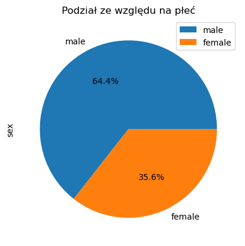

```python
# Policzenie liczby wystąpień każdej kategorii
counts = df['sex'].value_counts()

# W tej linii kodu tworzymy obiekt 'counts', który jest seria danych z biblioteki pandas, wygenerowaną przez funkcję 'value_counts()' na kolumnie 'sex' naszej ramki danych 'df'.
# Funkcja 'value_counts()' zlicza unikalne wartości występujące w danej serii/kolumnie danych.
# W tym przypadku obiekt 'counts' będzie zawierał liczbę mężczyzn i kobiet (lub jakiekolwiek inne unikalne wartości w kolumnie 'sex') w naszej ramce danych.

counts.plot(kind='pie', autopct='%1.1f%%', legend=True)

# Ta linia kodu tworzy wykres kołowy na podstawie danych w obiekcie 'counts'. Parametr 'kind' służy do określenia typu wykresu, w tym przypadku jest to wykres kołowy ('pie').
# Parametr 'autopct' służy do formatowania etykiet danych. Tu '%1.1f%%' oznacza, że liczby będą wyświetlane z jednym miejscem po przecinku i będą zawierały symbol procenta
# Parametr 'legend' jest ustawiony na 'True', więc wykres będzie zawierał legendę.

plt.title("Podział ze względu na płeć")

# Ta linia kodu nadaje tytuł wykresowi
```

## Klasa biletu / pclass /

```python
df['pclass'].isna()

# Ten fragment kodu analizuje kolumnę o nazwie 'pclass' w 'df'. Metoda 'isna()' zwraca wartości True lub False dla każdego elementu w kolumnie,
# w zależności od tego, czy Jest NaN (Not a Number - nie jest liczbą), czy nie. Innymi słowy, jest to sposób sprawdzenia, czy jakiekolwiek dane w kolumnie 'pclass' brakują, są puste lub niezdefiniowane.
# (True = puste)
```

```
0       False
1       False
2       False
3       False
4       False
        ...
1304    False
1305    False
1306    False
1307    False
1308    False
Name: pclass, Length: 1309, dtype: bool
```

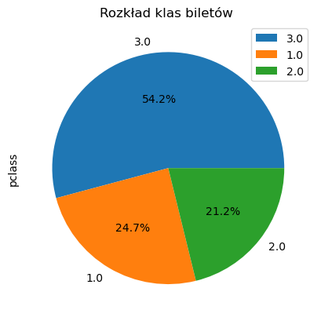

```python
klasa_biletu = df['pclass'].value_counts()

# Ten fragment kodu zlicza ile razy każda unikalna wartość (czyli każda klasa biletu) pojawia się w kolumnie 'pclass' DataFrame 'df',
# a następnie zapisuje te zliczone wartości w zmiennej 'klasa_biletu'.

klasa_biletu.plot(kind='pie', autopct='%1.1f%%', legend=True)
plt.title("Rozkład klas biletów ")

# komenda generuje wykres kołowy
```

- 24.7% pasażerowie z biletami w klasie 1
- 21.2% pasażerowie z biletami w klasie 2
- 54.2% pasażerowie z biletami w klasie 3

## Wiek pasażerów / age /

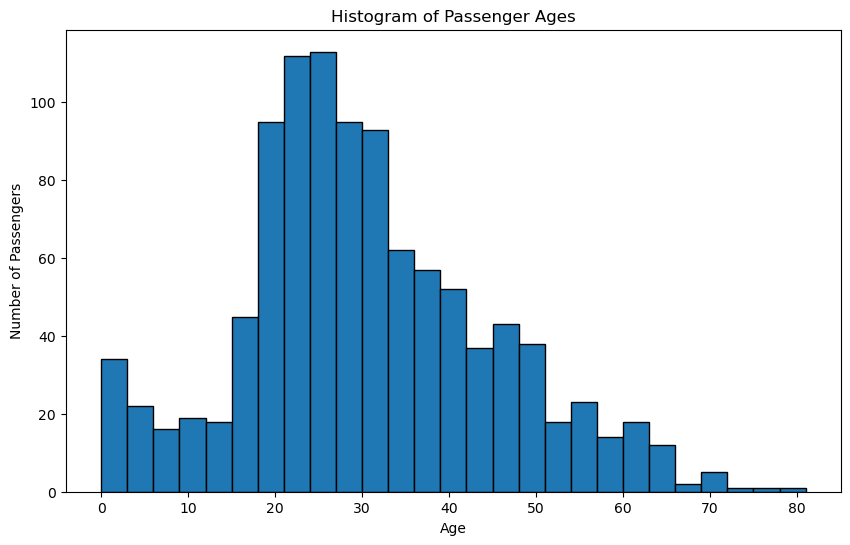

```python
age_data = df['age'].dropna()

# Ta linia kodu wyodrębnia dane dotyczące wieku (kolumna 'age') z ramki danych df i jednocześnie usuwa wszystkie brakujące wartości (NaN).
# Obiekt age_data staje się serią zawierającą wartości wieku.

plt.figure(figsize=(10, 6))
plt.hist(age_data, bins=range(0, int(age_data.max()) + 3, 3), edgecolor='black')
plt.title('Histogram of Passenger Ages')
plt.xlabel('Age')
plt.ylabel('Number of Passengers')

# Ta linia kodu inicjuje nowy wykres z określoną wielkością (szerokość=10, wysokość=6).
# Tworzymy histogram, którego dane pochodzą ze zmiennej age_data. Parametr bins określa, jak przedziały wiekowe (w latach) mają być grupowane, dzięki czemu każdy 'kosz' histogramu reprezentuje trzy lata.
# Krawędzie słupków histogramu są czarne.
# Nadajemy tytuł do naszego wykresu: 'Histogram of Passenger Ages'.
# Nadaję etykietę do osi x wykresu: 'Age'.
# Nadaję etykietę do osi y wykresu: 'Number of Passengers'.

plt.savefig('age_histogram.png')

# Ostatnia linijka kodu zapisuje wygenerowany wykres jako plik PNG o nazwie 'age_histogram.png'.
```

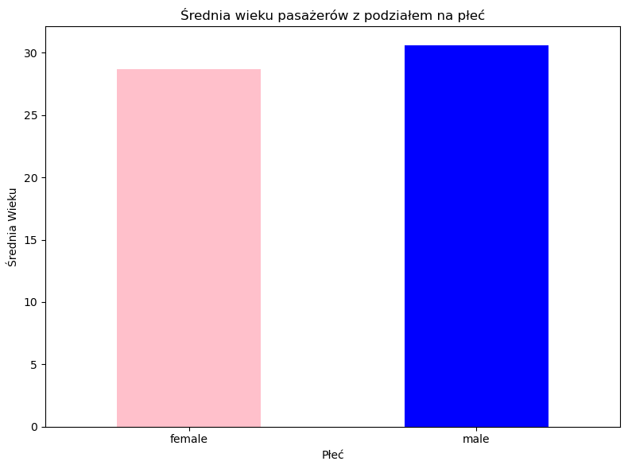

```python
df_filtered = df.dropna(subset=['age', 'sex'])

# Ten fragment kodu odpowiada za utworzenie nowego DataFrame'u 'df_filtered' na bazie oryginalnego DataFrame'u 'df'. Metoda 'dropna' usuwa wszystkie wiersze,
# które zawierają brakujące (czyli NaN) wartości dla kolumn 'age' lub 'sex'. W efekcie koniec naszego 'df_filtered' zawiera tylko wiersze, w których obie te kolumny mają określone wartości.

age_by_sex = df_filtered.groupby('sex')['age'].mean()

# Następnie kod grupuje 'df_filtered' przez kolumnę 'sex', oblicza średnią wartość wieku (kolumna 'age') dla każdej z tych grup i przypisuje wynik do zmiennej 'age_by_sex'.
# Wynikiem jest Series z indeksem opartym na unikalnych wartościach płci i wartościami średniego wieku dla każdej z płci.

plt.figure(figsize=(8, 6))
age_by_sex.plot(kind='bar', color=['pink', 'blue'])
plt.title('Średnia wieku pasażerów z podziałem na płeć')
plt.xlabel('Płeć')
plt.ylabel('Średnia Wieku')
plt.xticks(rotation=0)
plt.tight_layout()

# Generuje wykres, a następnie go zapisuje.

plot_filename = "Średnia wieku pasażerów z podziałem na płeć.png"
plt.savefig(plot_filename)
```

## Liczba rodzeństw i małżonków na pokładzie / sibsp /

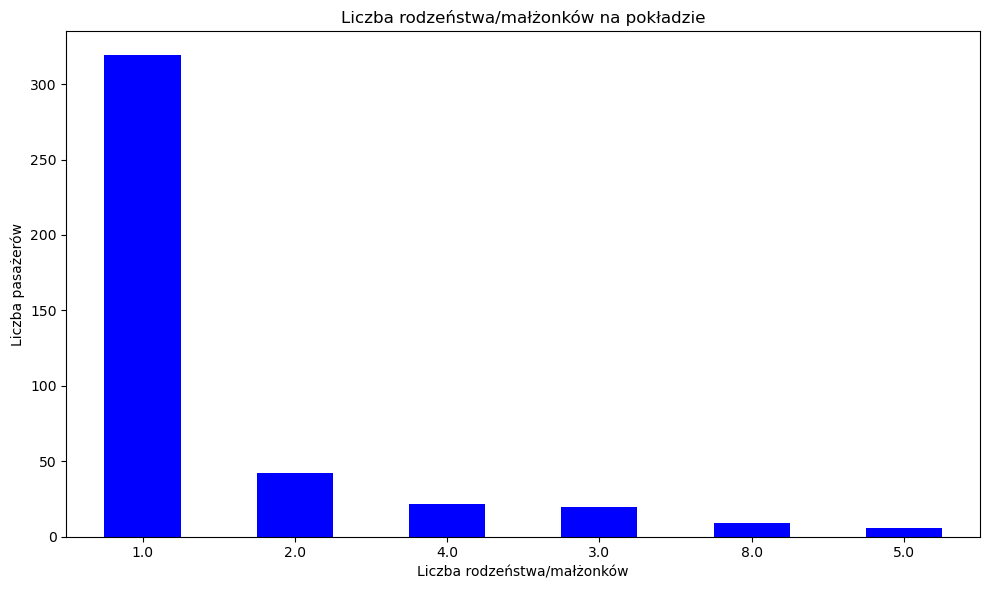

```python
df_filtered = df.dropna(subset=['sibsp'])

# W tej linii wykonujemy operację usunięcia wszystkich wierszy DataFrame, które mają wartości NaN (brak danych) w kolumnie 'sibsp'.
# Stworzony jest nowy DataFrame 'df_filtered', który zawiera tylko te wiersze, które mają wartości dla 'sibsp'.

df_filtered = df_filtered[df_filtered['sibsp'] > 0]

# Teraz mamy nowy DataFrame 'df_filtered', w którym wszystkie wiersze mają wartość 'sibsp' większą niż 0. W ten sposób odfiltrujemy wszelkie zerowe wartości 'sibsp'.

sibsp_counts = df_filtered['sibsp'].value_counts()

# Następnie, policz używając metody 'value_counts()' na kolumnie 'sibsp' i zapisz wynik do zmiennej 'sibsp_counts'.
# Wynik to seria liczba instancji dla każdej unikalnej wartości 'sibsp' w 'df_filtered'.

plt.figure(figsize=(10, 6))
sibsp_counts.plot(kind='bar', color='blue')
plt.title('Liczba rodzeństwa/małżonków na pokładzie')
plt.xlabel('Liczba rodzeństwa/małżonków')
plt.ylabel('Liczba pasażerów')
plt.xticks(rotation=0)
plt.tight_layout()

plot_filename = "sibsp_chart.png"
plt.savefig(plot_filename)

# Następnie zapiszemy wygenerowany wykres jako plik png. Nazwa pliku to 'sibsp_chart.png'.

total_passengers = len(df)

# Teraz obliczamy całkowitą liczbę pasażerów, która jest równa liczbie wierszy w DataFrame 'df'. Używamy do tego funkcji 'len'.

result = {
    "type": "plot",
    "value": plot_filename,
    "description": f"Liczba pasażerów z rodzeństwem/małżonkami na pokładzie: {total_passengers}."}

# Na końcu przygotowujemy wynik jako słownik zawierający typ wyniku (wykres), nazwę pliku z wykresem, i opis.
```

- Wynik trochę zaskakuje była rodzina z ośmirgiem i pięciorgiem dzieci...

## Liczba rodziców / dzieci na pokładzie

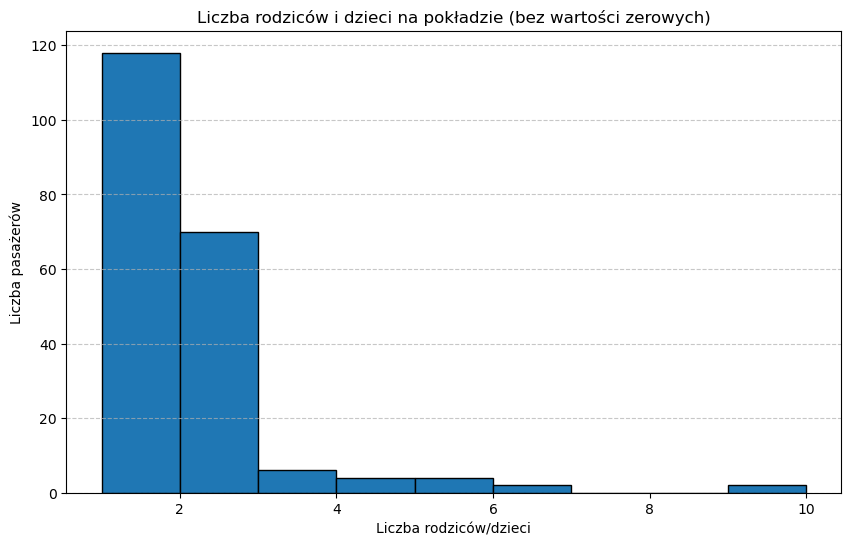

```python
filtered_df = df[df['sibsp'] > 0]

plt.figure(figsize=(10, 6))
plt.hist(filtered_df['parch'], bins=range(1, int(filtered_df['parch'].max()) + 2), edgecolor='black')

# Poniższy fragment kodu tworzy histogram dla kolumny „parch” ramki danych filtered_df. „bins” określa przedziały dla każdego słupka histogramu,
# które powinny mieścić się w zakresie od 1 do maksymalnej wartości w kolumnie „parch”. Kolor krawędzi każdego słupka histogramu jest czarny.

plt.title('Liczba rodziców i dzieci na pokładzie (bez wartości zerowych)')
plt.xlabel('Liczba rodziców/dzieci')
plt.ylabel('Liczba pasażerów')
plt.grid(axis='y', linestyle='--', alpha=0.7)

# Zapisz przed pokazaniem, ponieważ po poleceniu show bieżąca figura zostanie wyczyszczona w matplotlib.

plot_filename = "parch_histogram.png"
plt.savefig(plot_filename)

# Wyświetl wykres

plt.show()
plt.close()

result = {
    "type": "plot",
    "value": plot_filename
}
```

- Dane dla sibsp i parch nie są jednoznaczne ponieważ łączą w sobie po dwie grupy społeczne w każdej kolumnie.

## Ceny biletów

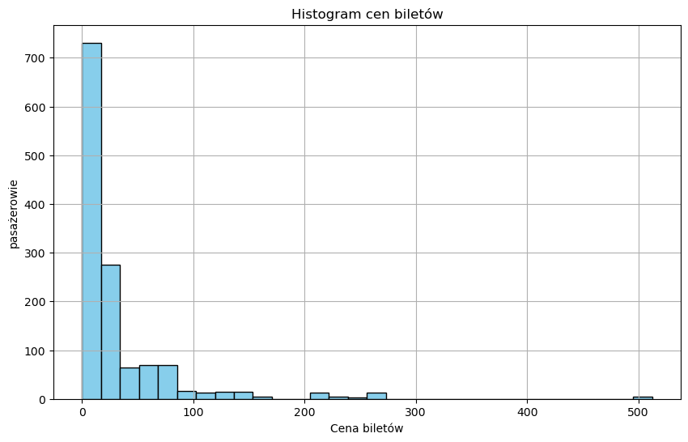

```python
fare_data = df['fare'].dropna()

# W pierwszych liniach kodu jest tworzona zmienna 'fare_data', która zawiera dane z kolumny 'fare' DataFrame'u 'df'. Metoda 'dropna()' oznacza, że wszystkie wartości 'NaN' (Not a Number) są usunięte.
# W praktyce oznacza to, że z oryginalnego zestawu danych eliminowane są wszystkie rekordy zawierające brakujące wartości.

plt.figure(figsize=(10, 6))
plt.hist(fare_data, bins=30, color='skyblue', edgecolor='black')
plt.title('Histogram cen biletów')
plt.xlabel('Cena biletów')
plt.ylabel('pasażerowie')
plt.grid(True)

# Save the plot as a PNG file
plt.savefig('fare_histogram.png')
```

## Port zaokrętowania pasażerów

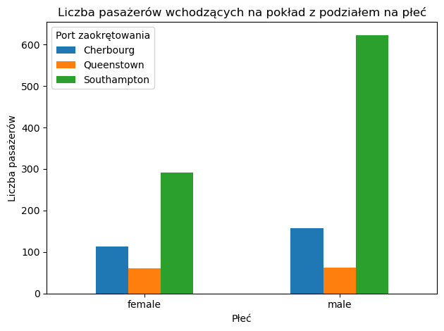

```python
df_filtered = df.dropna(subset=['sex', 'embarked'])

# Ten fragment kodu służy do czyszczenia danych w ramce danych o nazwie 'df'. Konkretnie używa metody 'dropna', aby usunąć (lub 'drop') wszystkie wiersze,
# które mają brakujące wartości (NaN) dla kolumn 'sex' i 'embarked'. Wynikowe oczyszczone dane są przechowywane w nowej ramce danych o nazwie 'df_filtered'.

passenger_counts = df_filtered.groupby(['sex', 'embarked']).size().unstack()

# Kod ten jest używany do grupowania i liczenia danych. 'groupby' jest funkcją w pandas, która grupuje dane według określonych kolumn ('sex' i 'embarked').
# Następnie 'size' liczy rozmiar każdej grupy, a 'unstack' zmienia kształt wynikowej serii danych tak, aby miała formę tabeli.

passenger_counts.plot(kind='bar', stacked=False)

# Ten kod odpowiada za stworzenie wykresu słupkowego (ang. bar plot) z naszych danych. Parametr 'stacked=True' sprawia, że słupki różnych grup są zestakowane, zamiast być ustawione obok siebie.

plt.title('Liczba pasażerów wchodzących na pokład z podziałem na płeć')
plt.xlabel('Płeć')
plt.ylabel('Liczba pasażerów')
plt.xticks(rotation=0)
plt.legend(title='Port zaokrętowania', labels=['Cherbourg', 'Queenstown', 'Southampton'])
plt.tight_layout()
plt.savefig('passenger_boarding.png')

# Te linie kodu ustawiają tytuł wykresu, etykiety osi X i Y, orientację etykiet na osi X (obrót = 0 stopni), legendę i zapisują wykres jako plik o nazwie 'passenger_boarding.png'.

result = {
    "type": "plot",
    "value": "passenger_boarding.png"
}
# Na końcu jest tworzony obiekt 'result'. Jest to słownik, który zawiera informacje o rodzaju wyniku (tutaj 'plot', co oznacza wykres) i ścieżkę do pliku z wykresem.
```

## Liczba łodzi i ciał

```python
unique_boats = df['boat'].dropna().unique()
unique_boat_count = len(unique_boats)
print(unique_boat_count)
```

```
27
```

```python
unique_body_count = df['body'].nunique()

result = {
    "type": "number",
    "value": unique_body_count
}
print(unique_body_count)
```

```
121
```

- Żródła podają że łodzi ratunkowych było 20, więc jest tu spora rozbieżność, zidentyfikowano 121 ciał podczas akcji ratunkowej.